# Exploratory Data Analysis (and a tinge of statistics)

**Learning Objectives**

- Produce histograms, barplot, boxplots, violin plots and scatterplots plot using ggplot.
- Describe what faceting is and apply faceting in ggplot.
- Modify the aesthetics of an existing ggplot plot (including axis labels and color).
- Build complex and customized plots from data in a data frame.
- Be wowed by the power of R and compelled to keep using it after this workshop

# Data types are important

The type of statistical analysis you will conduct depends critically on the type of data you have. In the time we have available it is not possible to go through every possible iteration of data and analysis. We also seek to link data visualization in tandem with statistics through *exploratory data analysis* or EDA, of our data. We will use EDA to get a sense of the distribution of our data, and see whether there are outliers or missing values. We will let the EDA inform us how to build our models.

### The Five Number Summary

The five number summary gives a quick look at the features of numerical variables. It consists of the variables:

- minimum
- 1st quartile
- median
- 3rd quartile
- maximum

**QUANTILES:** The *pth* percentile of a data set sorted from smallest to largest is the value such that *p* percent of the data are at or below this value. The quartiles are special percentiles; the 1st quartile is the 25th percentile, and the 3rd quartile is the 75th percentile. The median is also a quartile – it is the 50th percentile.

Within these five numbers is a lot of useful data!

- the median gives a measure of the center of the data
- the minimum and maximum give the range of the data
- the 1st and 3rd quartiles give a sense of the spread of the data, especially when compared to the minimum, maximum, and median

Load the data:

```r
download.file("http://home.cc.umanitoba.ca/~gersteia/MBIO7040/Calb_resistance.csv",
              here("data_in", "Calb_resistance.csv"))

Calb_R <- read_csv(here("data_in", "Calb_resistance.csv"))
glimpse(Calb_R)
```

```
## Observations: 501
## Variables: 5
## $ strain        <chr> "s498", "s499", "s465", "s480", "s481", "s466", "s…
## $ type          <chr> "blood", "blood", "blood", "blood", "blood", "bloo…
## $ gender        <chr> "f", "f", "f", "f", "f", "f", "m", "m", "f", "f", …
## $ `MIC (ug/mL)` <dbl> 128, 128, 32, 64, 64, 32, 64, 64, 64, 64, 64, 64, …
## $ `disk (mm)`   <dbl> 6, 6, 12, 12, 12, 13, 13, 13, 13, 13, 13, 13, 14, …
```

First I’m going to rename the two numerical variables to remove the unit information. It’s useful but unnecessary. You can see that there are quotes around the column names and this isn’t ideal. Since we’re keeping a script of all the steps are are taking, the information won’t really be lost anyways. I’m going to break one of my rules and overwrite the original tibble without changing the name because I like this name and I haven’t actually done anything to alter the data itself, just how we access it.

```r
Calb_R <- Calb_R %>%
  rename(MIC = `MIC (ug/mL)`, disk = `disk (mm)`)
glimpse(Calb_R)
```

```
## Observations: 501
## Variables: 5
## $ strain <chr> "s498", "s499", "s465", "s480", "s481", "s466", "s482", "…
## $ type   <chr> "blood", "blood", "blood", "blood", "blood", "blood", "bl…
## $ gender <chr> "f", "f", "f", "f", "f", "f", "m", "m", "f", "f", "f", "f…
## $ MIC    <dbl> 128, 128, 32, 64, 64, 32, 64, 64, 64, 64, 64, 64, 32, 32,…
## $ disk   <dbl> 6, 6, 12, 12, 12, 13, 13, 13, 13, 13, 13, 13, 14, 14, 14,…
```

We’ll going to use a new function `skim()` from the `skimr` package to look at the summary information for the numerical variables of interest.

```r
#install.packages("skimr")
library(skimr)
#select the columns with our data of interest.
Calb_R %>%
  select(MIC, disk) %>%
  skim()
```

```
## Skim summary statistics
##  n obs: 501
##  n variables: 2
##
## ── Variable type:numeric ────────────────────────────────────────────────────────────────────────────────────
##  variable missing complete   n  mean    sd   p0   p25  p50 p75 p100
##      disk       6      495 501 32.56  7.25 6    30    34    37   50
##       MIC       9      492 501  5.08 16.84 0.12  0.25  0.5   1  128
##      hist
##  ▁▂▁▁▆▇▂▁
##  ▇▁▁▁▁▁▁▁
```

`Skim()` gives us the five numbers, as well as the sample size (`n`), the mean, and the standard deviation `sd`. We also get a quick snapshot of the histogram of values.

In this case the two variables give us quite different results. For the *disk* parameter, the mean and median (*p50*) are very similar, while for the MIC results they are quite different. We say that the *mean* is not a **robust** statistic since it is not resistant to extreme observations. In contrast, the *median* is robust to extreme (or outlier) observations. This summary (as well as the histogram) tells us that there is a **skew** in the data for MIC the data is not symmetrical around the median. It also gives us information about differences between these two types of experiments that seek to capture the same data, and perhaps suggests that outliers in MIC experiments are more common than in disk diffusion experiments.

We’re going to explore these concepts more through the second phase of EDA, plotting the data. To do that we’ll use `ggplot`, which was actually one of the first developed components of the `tidyverse` framework that we’ve been using is this workshop. `ggplot` was actually first developed as a PhD thesis chapter!

# Plotting with `ggplot2`

`ggplot2` is a plotting package that makes it simple to create complex plots from data in a data frame. It provides a more programmatic interface for specifying what variables to plot, how they are displayed, and general visual properties. Therefore, we only need minimal changes if the underlying data change or if we decide to change from a bar plot to a scatterplot. This helps in creating publication quality plots with minimal amounts of adjustments and tweaking.

`ggplot2` functions like data in the ‘long’ format, i.e., a column for every dimension, and a row for every observation. Well-structured data will save you lots of time when making figures with `ggplot2`.

`ggplot` graphics are built step by step by adding new elements. Adding layers in this fashion allows for extensive flexibility and customization of plots.

To build a ggplot, we will use the following basic template that can be used for different types of plots:

`ggplot(data = <DATA>, mapping = aes(<MAPPINGS>)) + <GEOM_FUNCTION>`

Use the ggplot() function and bind the plot to a specific data frame using the data argument `ggplot(data = Calb_R)`

Define a mapping (using the aesthetic (aes) function), by selecting the variables to be plotted and specifying how to present them in the graph, e.g. as x/y positions or characteristics such as size, shape, color, etc. `ggplot(data = Calb_R, mapping = aes(x = MIC, y = disk))`. In the context of this workshop we won’t have too much time to talk about the philosophy of visualization, but I want to point you to a wonderful new book on this that is available free online. It’s actually a really accessible book that could probably be read in it’s entirety in a day. (Fundamental of Data Visualization by Clause Wilke)[https://serialmentor.com/dataviz/].

So we’ve told R the data we want to plot, but not how we want it plotted. For that we need to add ‘geoms’ – graphical representations of the data in the plot (points, lines, bars). `ggplot2` offers many different geoms; we will use some common ones today, including:  
- `geom_histogram()` for (unsurprisingly) histograms  
- `geom_boxplot()` for, well, boxplots!  
- `geom_bar()` for bar plots  
- `geom_point()` for scatter plots, dot plots, etc.  
- `geom_line()` for trend lines, time series, etc.

## Principles of effective display

SOURCE: (Whitlock & Schluter, The Analysis of Biological Data)[http://whitlockschluter.zoology.ubc.ca/]

We will follow these metrics to create and evaluate figures:  
1. Show the data  
2. Make patterns in the data easy to see  
3. Represent magnitudes honestly  
4. Draw graphical elements clearly, minimizing clutter

## Plotting the distribution of one varible

Let’s first look at a couple very simple plots to see what our data looks like. I like to refer to this step as touching the data or interacting with the data. I think one of the best things about R is that graphs are really cheap - we can make quick and dirty graphs really easily and (hopefully) gain a lot of insight about the data just by plotting alone.

First we’ll explore the spread of the different variables. We’ll start with a histogram of the disk diffusion resistance:

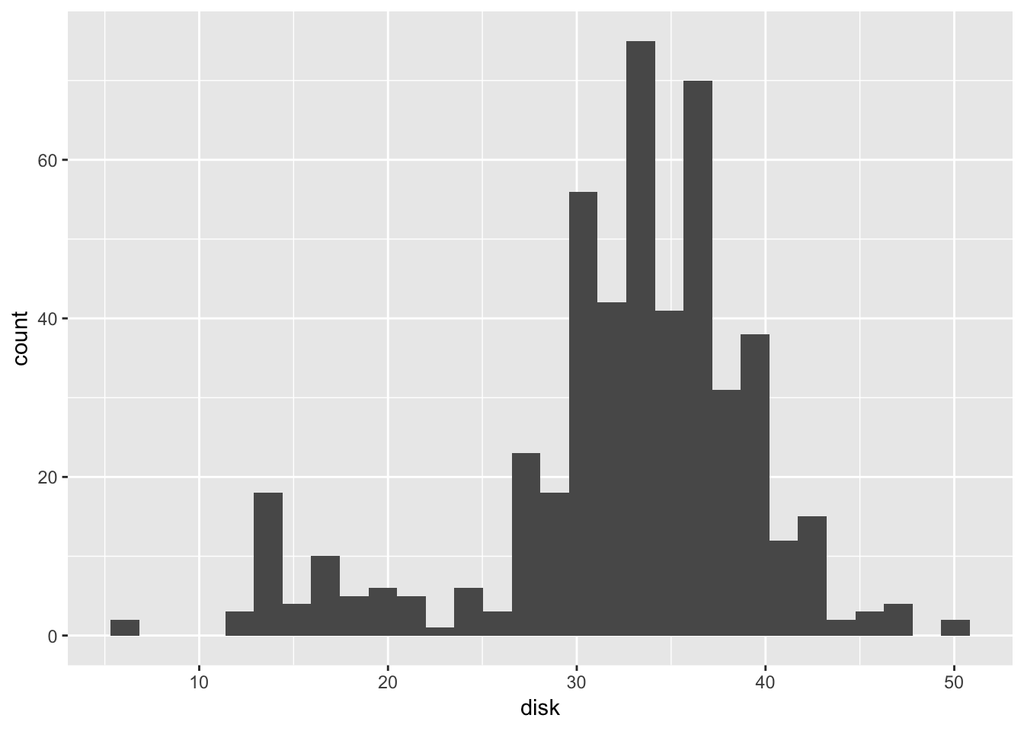

```r
ggplot(data = Calb_R, mapping = aes(disk)) +
  geom_histogram()
```

If we use the help menu to look up `geom_histogram` ( or type `?geom_histogram` directly into the console), the description tells us what is happening: “Visualise the distribution of a single continuous variable by dividing the x axis into bins and counting the number of observations in each bin. Histograms (geom_histogram()) display the counts with bars; frequency polygons (geom_freqpoly()) display the counts with lines.” If you scroll down and look through the arguments, you can see all the different things we can change that will alter how the data is presented. For histograms, there’s actually two different ways to specify bins. The first is through `bins`, which is the number of bins to break the data into. This is the default, and the message here has told us that the default was 30, and it prompts us to purposefully decide if this is what we want or not. The other option is to specify a `binwidth`, which can be either a numeric value or a function that calculates width from x. These help files often contain a lot of useful information, and I recommend you spend some time reading them.

Let’s play a bit with changing the the number of bins (which the help file tells us we should always do). I’ve done this type of experiments before, and I can use my expert knowledge to make this decision. In this case I suggest choosing a binwidth of 1, because 1mm is a natural unit for this type of data.

```r
ggplot(data = Calb_R, mapping = aes(disk)) +
  geom_histogram(binwidth = 1)
```

```r
Calb_R %>%
  filter(is.na(disk))
```

```
## # A tibble: 6 x 5
##   strain type  gender   MIC  disk
##   <chr>  <chr> <chr>  <dbl> <dbl>
## 1 s317   blood f      NA       NA
## 2 s318   blood f      NA       NA
## 3 s344   blood f       1       NA
## 4 s28    oral  m       0.12    NA
## 5 s146   skin  m       0.25    NA
## 6 s147   skin  m       0.25    NA
```

We can get rid of that using the same nomenclature as before `na.rm = TRUE` within our ggplot function.

Note that we actually have options for how we specify this exact same figure. The `aes` can actually be set in either the original `ggplot` call or in the `geom_*` call. If you set them in the original `ggplot` they are inherited by any other geom’s that build on top of that (unless you override it by specifying specific `aes` in the `geom`). If you specify the `aes` in a `geom`, it will only be used in that `geom`. e.g.,

```r
ggplot(data = Calb_R) +
  geom_histogram(mapping = aes(disk), binwidth =1, na.rm = TRUE)
```

The difference is that when the aes are set in the original ggplot , they are inherited by any other geom’s that build on top of it. If you specify the aes only in a geom, it will only be used in that geom. If you use any specific aes in geom , they override the settings in ggplot

We can also specify `binwidth` using a different layer in the `ggplot` call, `stat_bin` instead of `geom_histogram`.

```r
ggplot(data = Calb_R) +
#  geom_histogram(mapping = aes(disk)) +
  stat_bin(mapping = aes(disk), binwidth = 1)
```

The difference between geom and stat layers is somewhat nuanced and I refer you to this stackoverflow (post)[https://stackoverflow.com/questions/38775661/what-is-the-difference-between-geoms-and-stats-in-ggplot2]. “*geoms* stand for”geometric objects." These are the core elements that you see on the plot, object like points, lines, areas, curves. *stats* stand for “statistical transformations.” These objects summarize the data in different ways such as counting observations, creating a loess line that best fits the data, or adding a confidence interval to the loess line. … these distinctions are somewhat conceptual as the majority of geoms undergo some statistical transformation prior to being plotted." Let’s leave it at that (but have a read of the full post if you’re interested).

There are a few easy things we can do to change this plot. We can easily change the theme (I personally don’t like the grey background) and the axis labels. In reality if you can think of something to change, it can be done. The nice thing is that once we develop the code to specify the format we like, we can just copy it as we go forward.

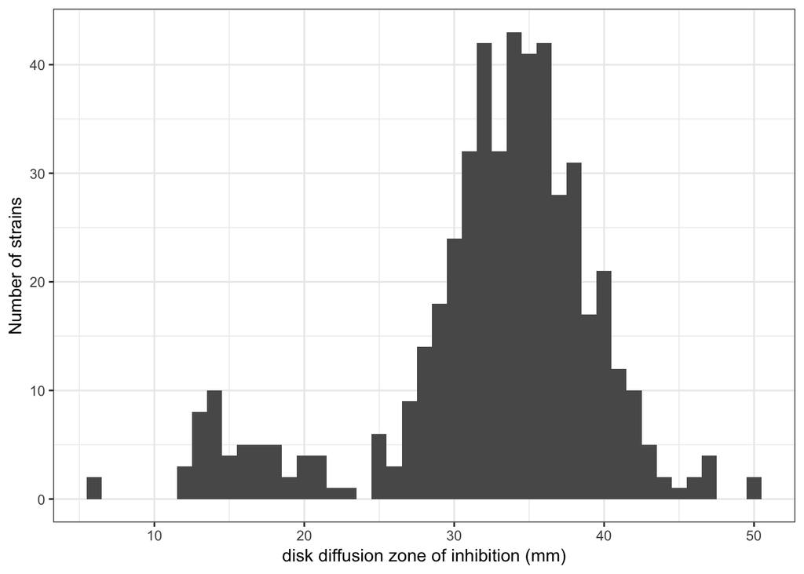

```r
ggplot(data = Calb_R, mapping = aes(disk)) +
  geom_histogram(binwidth = 1) +    # change the number of bins
  theme_bw() +   # change the theme
  labs(x = "disk diffusion zone of inhibition (mm)" , y = "Number of strains")
```

### EXERCISE

By eye, does this variable look normally distributed? Why or why not?

We can statistically test for normality using the `shapiro.test()`:

```r
shapiro.test(Calb_R$disk)
```

```
##
##  Shapiro-Wilk normality test
##
## data:  Calb_R$disk
## W = 0.89958, p-value < 2.2e-16
```

Notice that we switched syntaxes above, to *base* R (i.e., we used `df$variable`). The majority, if not all of the common statistical tests require this syntax, because they were developed prior to the *tidyverse* set of commands. Although there are some workarounds, we’re going to go back and forth a little bit from these two syntaxes as required.

## Plotting with multiple types of data

We can also easily overlay information from a categorical variable in this data set. In this case we’ll add the strain `type` information using the `fill` command within the aesthetics specification.

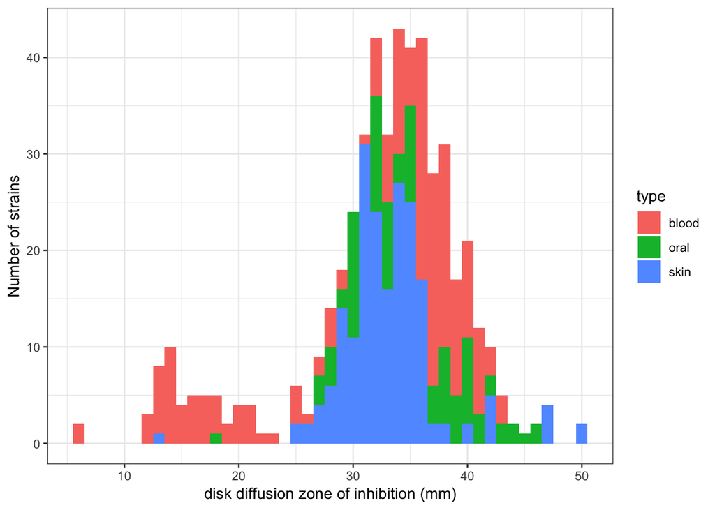

```r
ggplot(data = Calb_R, mapping = aes(disk, fill = type)) +
  geom_histogram(binwidth = 1, na.rm = TRUE) +    # change the number of bins
  theme_bw() +   # change the theme
  labs(x = "disk diffusion zone of inhibition (mm)" , y = "Number of strains")
```

We could accomplish a related visualization by separating this into three different panels using the function `facet_wrap`:

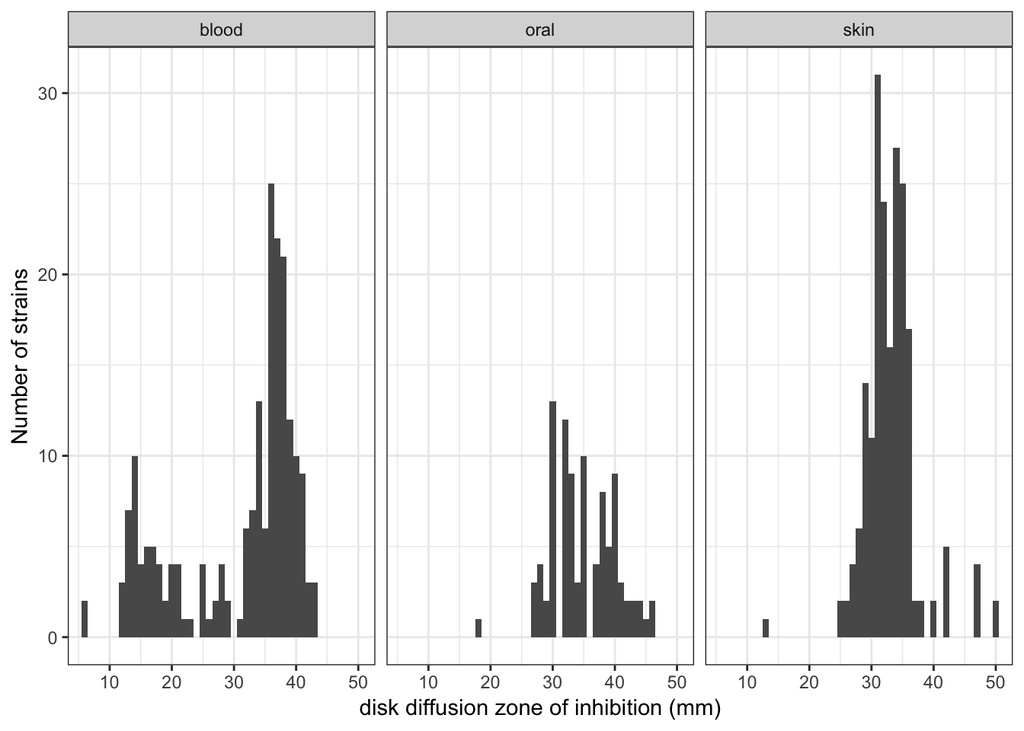

```r
ggplot(data = Calb_R, mapping = aes(disk)) +
  geom_histogram(binwidth = 1, na.rm = TRUE) +
  theme_bw() +
  labs(x = "disk diffusion zone of inhibition (mm)" , y = "Number of strains") +
  facet_wrap(~type)
```

We can see here quite clearly that we have different amounts of data in each of these categories. Sometimes instead of plotting counts data it can also be helpful to visualize this as the density of the data. In this case we use a different (but related) geom, `geom_freqpoly`, and also need to specify that the stat we want is density.

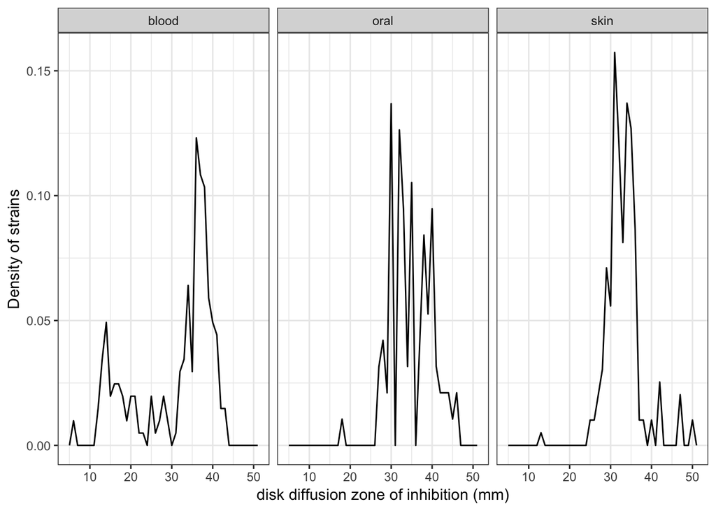

```r
ggplot(data = Calb_R, mapping = aes(disk)) +
  geom_freqpoly(mapping = aes(disk, stat(density)), binwidth = 1, na.rm = TRUE) +
  theme_bw() +
  labs(x = "disk diffusion zone of inhibition (mm)" , y = "Density of strains") +
  facet_wrap(~type)
```

I don’t actually think we gain that much in this case (and actually lose the intuitive ability to see that there are different numbers of strains in the different groups) but I wanted to demonstrate how easy it is to do fairly complicated data transformations for visualization with very minor adjustments to the code.

### EXERCISE:

Create a new figure with two panels, one panel for each `gender` that colours the different strain types differently. Use the help menus or “google fu” to figure out how to add a title to the figure (whatever you like). Since dividing up the data into six categories makes it a bit sparse, play around with either `bin` or `binwidth` to find something that looks more pleasing.

## Statistical tests

It’s probably time to do a statistical test, though having fairly extensively plotted (and interacted) with this data, we can probably intuit what the test will say.

First let’s ignore the different types and test whether disk diffusion MIC differed between strains isolated from men and women. To do that we’re going to use a two sample t-test. The assumptions of a t-test are normally-distributed data, which we already saw is not met. So instead we will do the non-parametric wilcoxon test (or Mann-Whitney U test) that compares data ranks instead.

```r
wilcox.test(disk ~ gender, data = Calb_R)
```

```
##
##  Wilcoxon rank sum test with continuity correction
##
## data:  disk by gender
## W = 30727, p-value = 0.928
## alternative hypothesis: true location shift is not equal to 0
```

We can similarly ignore gender and test the effect of type. In this case we have more than two groups, so we’re going to use an ANOVA test. In reality a t-test is the same thing as an ANOVA, just with two groups instead of more than two groups. The non-parametric equivalent of an ANOVA is the Kruskal-Wallis test, but the Kruskal-Wallis test assumes that sampled populations have identical shape and dispersion. We can see from our figure that this is not met. In this case it is actually better to use an ANOVA test. Although the ANOVA is parametric, it is considered a robust test against the normality assumption, that is non-normal data has only a small effect on the Type I error rate.

```r
aov(disk ~ type, data = Calb_R)
```

```
## Call:
##    aov(formula = disk ~ type, data = Calb_R)
##
## Terms:
##                      type Residuals
## Sum of Squares   1106.458 24891.534
## Deg. of Freedom         2       492
##
## Residual standard error: 7.112844
## Estimated effects may be unbalanced
## 6 observations deleted due to missingness
```

When you run the ANOVA we don’t actually get all the information we need out of just the model `aov` call. We need to wrap that in a second function to pull out additional information:

```r
anova_test <- aov(disk ~ type, data = Calb_R)
summary(anova_test)
```

```
##              Df Sum Sq Mean Sq F value   Pr(>F)
## type          2   1106   553.2   10.94 2.26e-05 ***
## Residuals   492  24892    50.6
## ---
## Signif. codes:  0 '***' 0.001 '**' 0.01 '*' 0.05 '.' 0.1 ' ' 1
## 6 observations deleted due to missingness
```

There’s the stats. We’re going to install one more package, the broom package, that will clean up this output.

```r
library(broom)
tidy(anova_test)
```

```
## # A tibble: 2 x 6
##   term         df  sumsq meansq statistic    p.value
##   <chr>     <dbl>  <dbl>  <dbl>     <dbl>      <dbl>
## 1 type          2  1106.  553.       10.9  0.0000226
## 2 Residuals   492 24892.   50.6      NA   NA
```

```r
glance(anova_test)
```

```
## # A tibble: 1 x 11
##   r.squared adj.r.squared sigma statistic p.value    df logLik   AIC   BIC
##       <dbl>         <dbl> <dbl>     <dbl>   <dbl> <int>  <dbl> <dbl> <dbl>
## 1    0.0426        0.0387  7.11      10.9 2.26e-5     3 -1672. 3352. 3369.
## # … with 2 more variables: deviance <dbl>, df.residual <int>
```

Using the broom functions `tidy` and `glance` we can easily access the parameter values:

```r
anova_test_tidy <- tidy(anova_test)
anova_test_tidy
```

```
## # A tibble: 2 x 6
##   term         df  sumsq meansq statistic    p.value
##   <chr>     <dbl>  <dbl>  <dbl>     <dbl>      <dbl>
## 1 type          2  1106.  553.       10.9  0.0000226
## 2 Residuals   492 24892.   50.6      NA   NA
```

```r
anova_test_tidy$p.value[1]
```

```
## [1] 2.256929e-05
```

If we want to know which groups are different from each other, we can use the post-hoc (or “after the event”) tukey test:

```r
TukeyHSD(anova_test)
```

```
##   Tukey multiple comparisons of means
##     95% family-wise confidence level
##
## Fit: aov(formula = disk ~ type, data = Calb_R)
##
## $type
##                 diff       lwr       upr     p adj
## oral-blood  3.965051  1.886492 6.0436086 0.0000271
## skin-blood  2.130479  0.458185 3.8027737 0.0080993
## skin-oral  -1.834571 -3.923196 0.2540533 0.0982914
```

In reality, we actually know that there are two different categorical variables here that could influence the disk diffusion resistance, and we can include them both in one test, a two-way ANOVA.

```r
full_anova_test <- aov(disk ~ type*gender, data = Calb_R)
tidy(full_anova_test)
```

```
## # A tibble: 4 x 6
##   term           df   sumsq meansq statistic    p.value
##   <chr>       <dbl>   <dbl>  <dbl>     <dbl>      <dbl>
## 1 type            2  1106.   553.     10.9    0.0000228
## 2 gender          1    13.6   13.6     0.269  0.604
## 3 type:gender     2   116.    58.0     1.15   0.319
## 4 Residuals     489 24762.    50.6    NA     NA
```

This hopefully tells us what we already intuited from the EDA: type but not gender influences disk resistance. If this is the story we want to tell, the histograms may not be the best method to do that. Let’s change to another geom method, `geom_boxplot`.

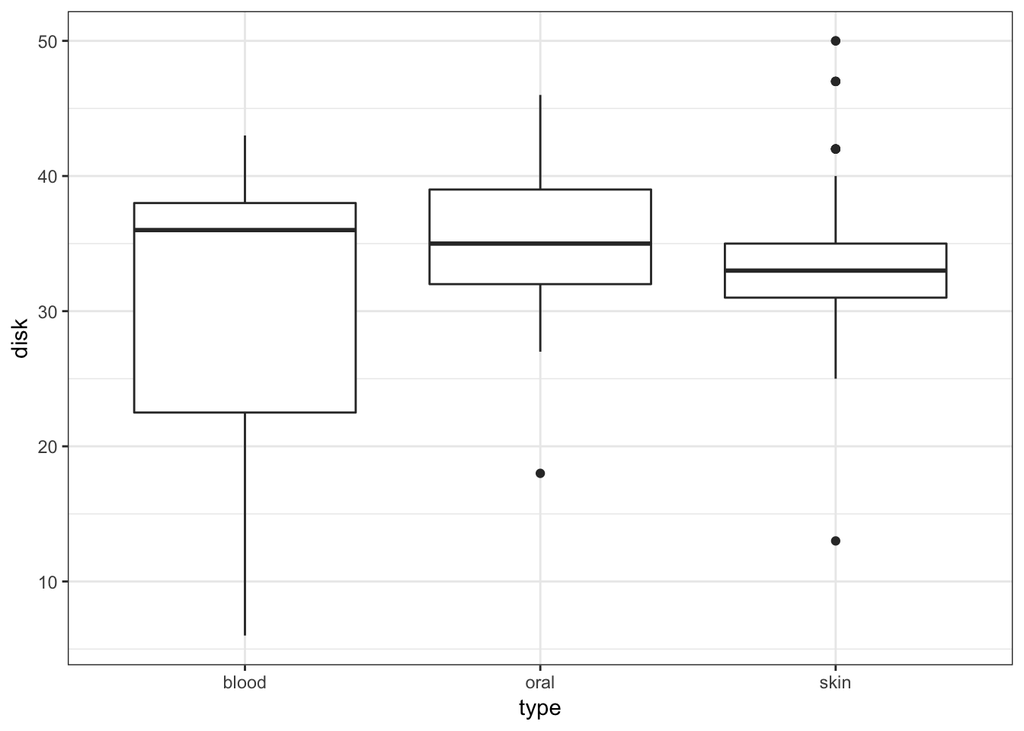

```r
ggplot(data = Calb_R) +
  geom_boxplot(mapping = aes(x = type, y = disk), na.rm = TRUE) +
  theme_bw()
```

I’m going to save this base figure as an object and then build it up:

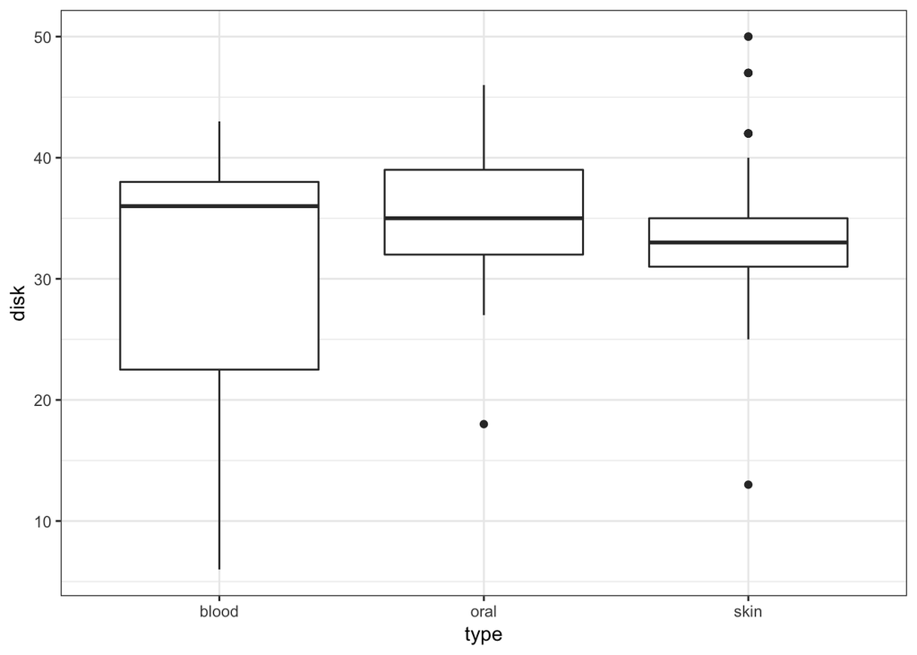

```r
p <- ggplot(data = Calb_R) +
  geom_boxplot(mapping = aes(x = type, y = disk), na.rm = TRUE) +
  theme_bw()
p
```

I’d like to change the axes labels (this is almost always true) and add the tukey test results using the `annotate` layer.

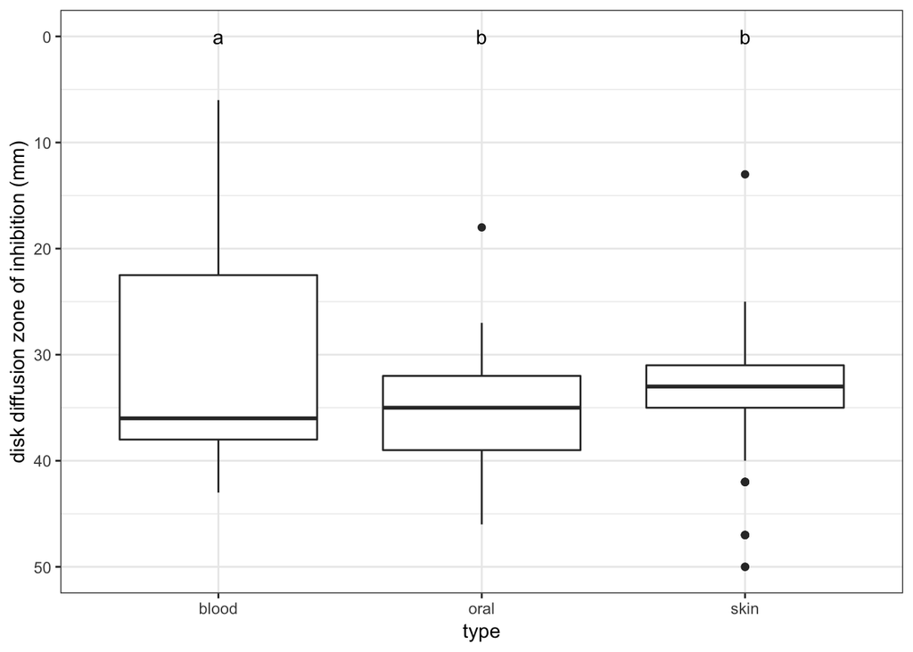

```r
p +
  scale_y_reverse(limits = c(50, 0)) +
  labs(y = "disk diffusion zone of inhibition (mm)" , y = "site of strain isolation") +
  annotate("text",x = c(1, 2, 3), y = c(0, 0, 0), label = c("a", "b", "b"))
```

And just as a quick aside, I don’t actually like boxplots all that much, since I think they aren’t that intuitive. A related alternative to the boxplot called a **violin plot** has been developed and is easily accessible through the ggplot framework. Again, in the interest of time I’ll refer you elsewhere for a more in-depth discussion. To start, [wikipedia](https://en.wikipedia.org/wiki/Violin_plot) is a good place to start.

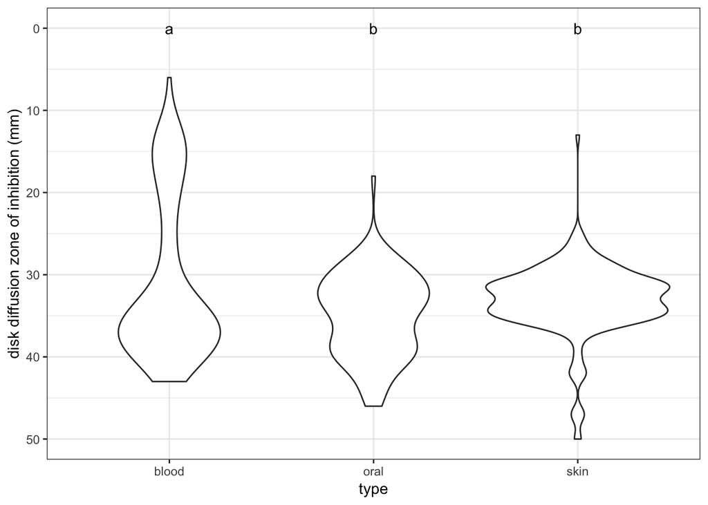

```r
p2 <- ggplot(data = Calb_R) +
  geom_violin(mapping = aes(x = type, y = disk), na.rm = TRUE) +
  theme_bw() +
  scale_y_reverse(limits = c(50, 0)) +
  labs(y = "disk diffusion zone of inhibition (mm)" , y = "site of strain isolation") +
  annotate("text",x = c(1, 2, 3), y = c(0, 0, 0), label = c("a", "b", "b"))

p2
```

We can also easily add different summary statistics directly on top, like the mean or the median.

```r
p2 +
  stat_summary(fun.y=mean, geom="point", shape=23, size=2)
```

Aha. Here is a case where it matters where we specify the aesthetics. Because they are defined in the geom and not the ggplot function, stat_summary doesn’t have access to the data.

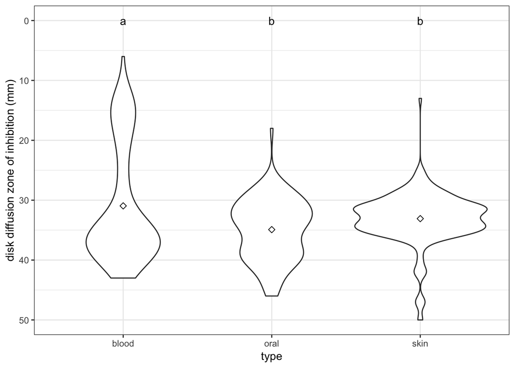

```r
p3 <- ggplot(data = Calb_R, mapping = aes(x = type, y = disk)) +
  geom_violin(na.rm = TRUE) +
  theme_bw() +
  scale_y_reverse(limits = c(50, 0)) +
  labs(y = "disk diffusion zone of inhibition (mm)" , y = "site of strain isolation") +
  annotate("text",x = c(1, 2, 3), y = c(0, 0, 0), label = c("a", "b", "b")) +
  stat_summary(fun.y=mean, geom="point", shape=23, size=2, na.rm = TRUE)

p3
```

We’re now going to look at our second continuous variable, resistance from MIC. We’ll start the same way, with a histogram:

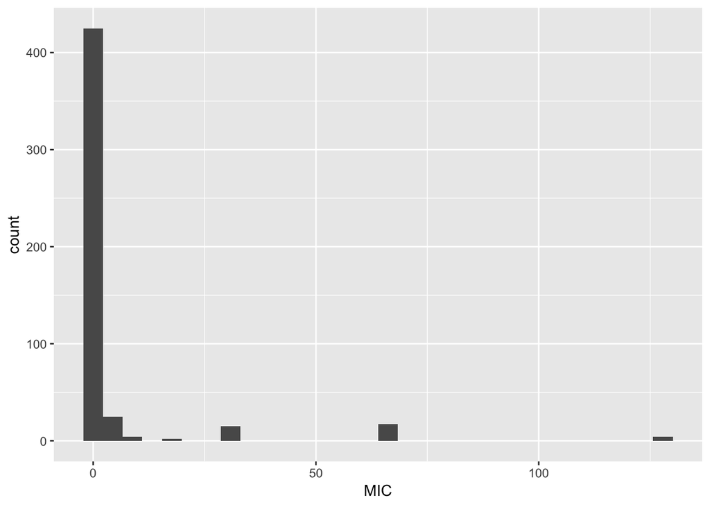

```r
pM <- ggplot(data = Calb_R, mapping = aes(MIC)) +
  geom_histogram(na.rm = TRUE)

pM
```

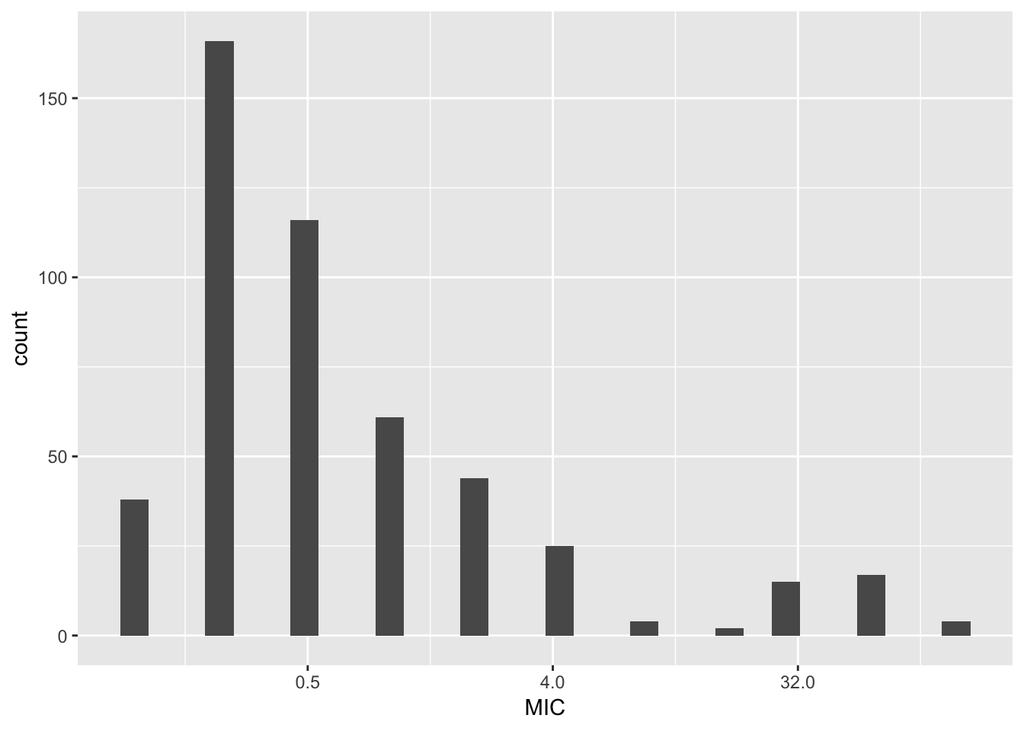

```r
pM +
  scale_x_continuous(trans="log2")
```

So given that, let’s switch to `geom_bar()`:

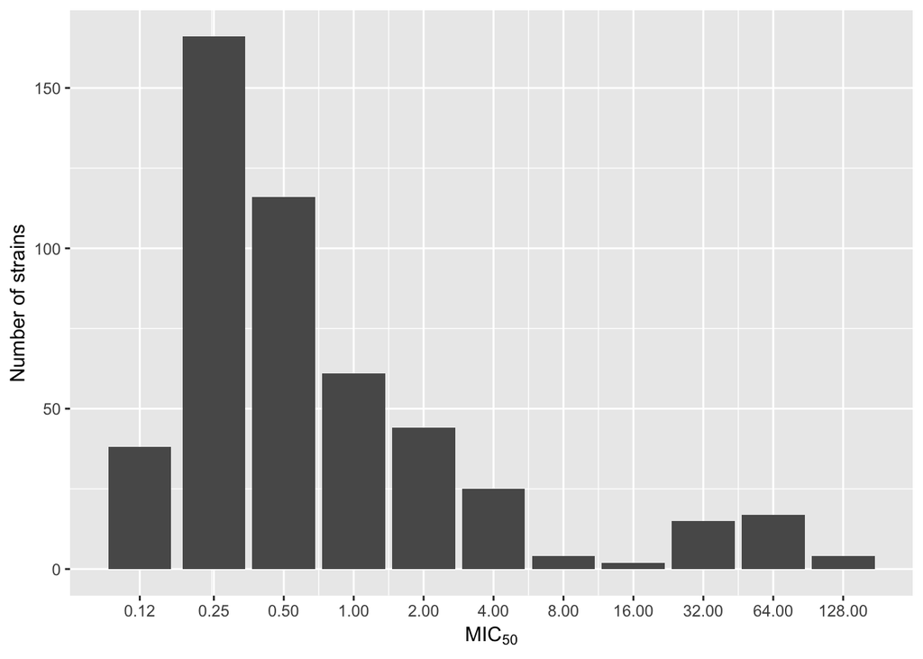

```r
ggplot(data = Calb_R, mapping = aes(MIC)) +
  geom_bar(na.rm = TRUE) +
  scale_x_continuous(trans="log2", breaks = unique(Calb_R$MIC)) +
  labs(x = expression(MIC[50]), y = "Number of strains")
```

What if I want to add the type information into this plot? We have to do this differently than we did before, because this is a different type of plot with a different type of data. What I think I’d like to do is present a bar plot with different coloured bars for each type beside each other. To do that I actually need a new tibble, one that calculates how many strains fall into each type x MIC group. We can turn back to our friends `group_by` and `summarize` to calculate this information for us, and then chain that directly into ggplot: (!!!)

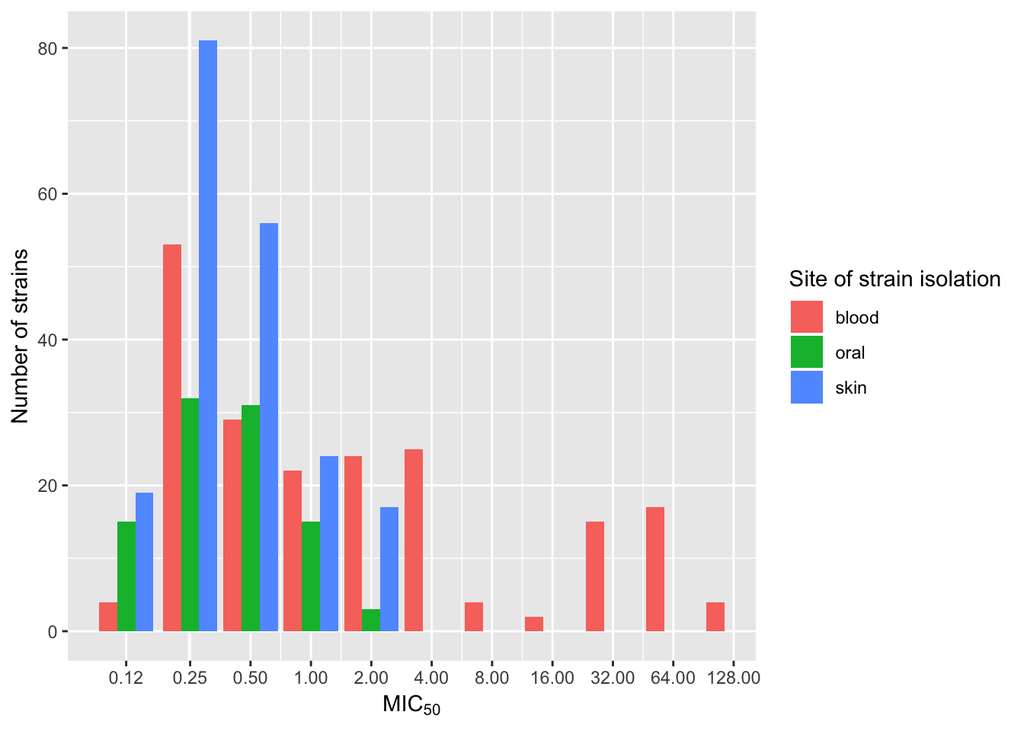

```r
Calb_R %>%
  group_by(type, MIC) %>%
  summarize(num_strains = n()) %>%
  ggplot(mapping = aes(MIC, num_strains, fill= type)) +
    geom_bar(stat = "identity", position=position_dodge(preserve = "single"), na.rm = TRUE) +
    scale_x_continuous(trans="log2", breaks = unique(Calb_R$MIC)) +
    labs(x = expression(MIC[50]), y = "Number of strains") +
    scale_fill_discrete(name = "Site of strain isolation")
```

### EXERCISE

1. Using the help menu, explore the options for `geom_bar`. What does `stat = "identity"` do? What about `position_dodge`? How do you change the width of the bar to be equal to the total width of all elements at a position.
2. Conduct a statistical test to determine whether type or gender (or their interaction) has a significant effect on MIC.

## Two continuous variables

Now we’re going to tie all this together. The goal of the original paper was to see whether the same resistance level is found when you use disk assays compared to broth microdilution. We’ll use `geom_point` for this task and I’m going to use all of the things we worked out above to specify the layers.

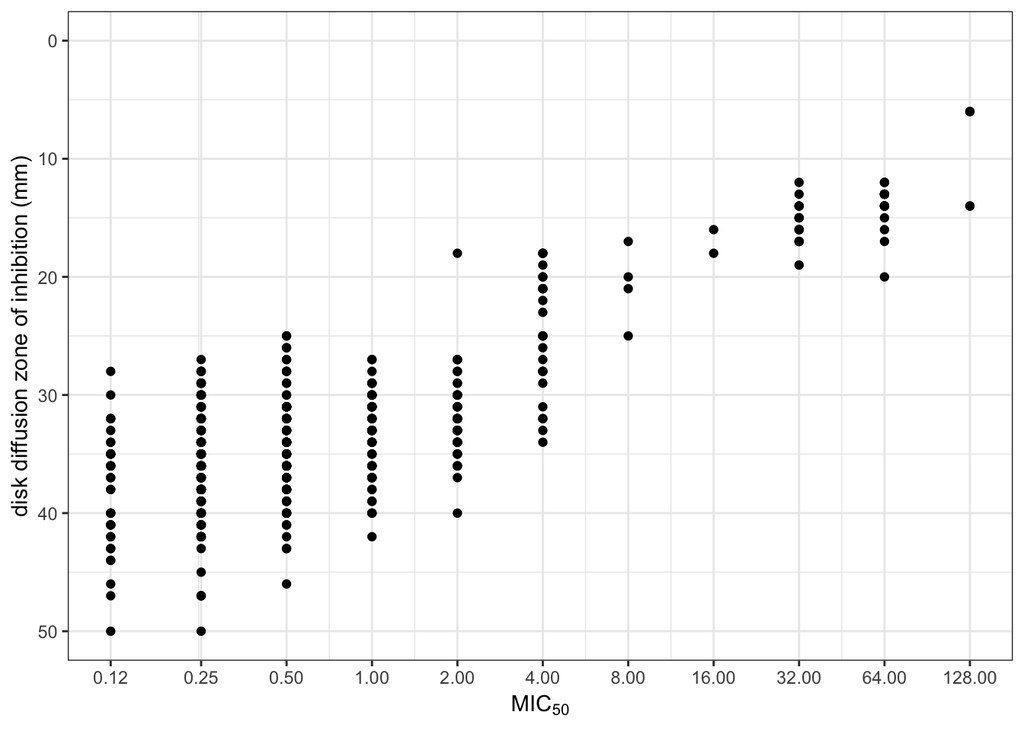

```r
gP <- ggplot(Calb_R, aes(MIC, disk)) +
  scale_x_continuous(trans="log2", breaks = unique(Calb_R$MIC)) +
  scale_y_reverse(limits = c(50, 0)) +
  labs(y = "disk diffusion zone of inhibition (mm)" , x = expression(MIC[50])) +
  theme_bw()

gP +
  geom_point(na.rm =TRUE)
```

That looks like a pretty solid relationship. We can add a second geom to this figure to add a line of fit:

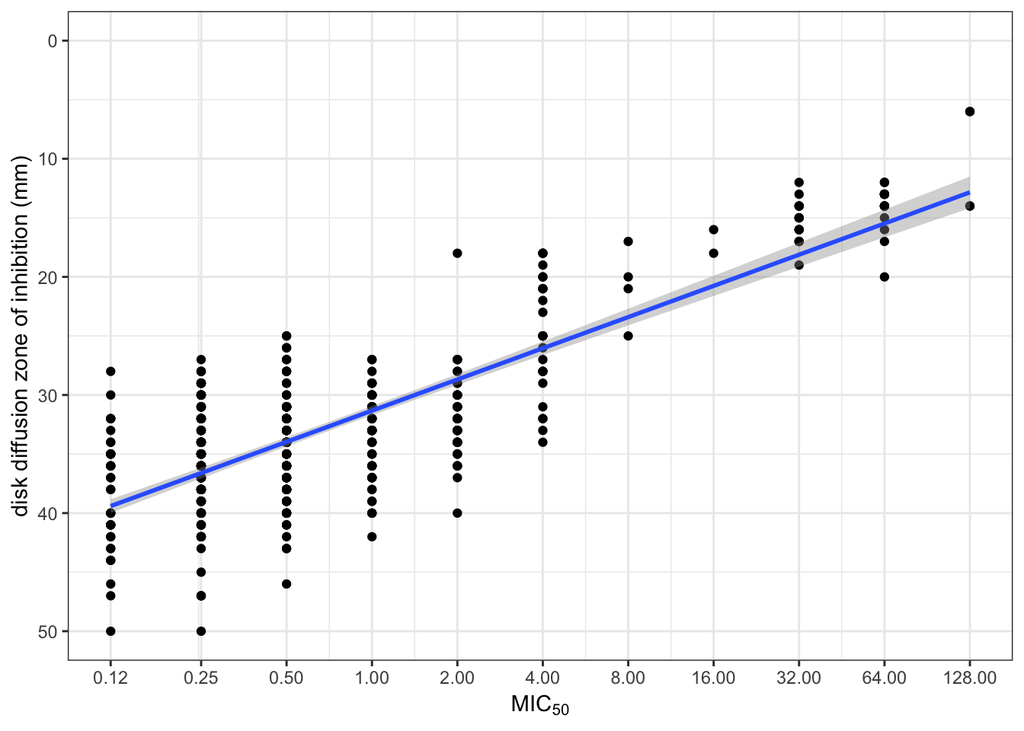

```r
gP +
  geom_point(na.rm =TRUE) +
  geom_smooth(method = "lm", na.rm=TRUE)
```

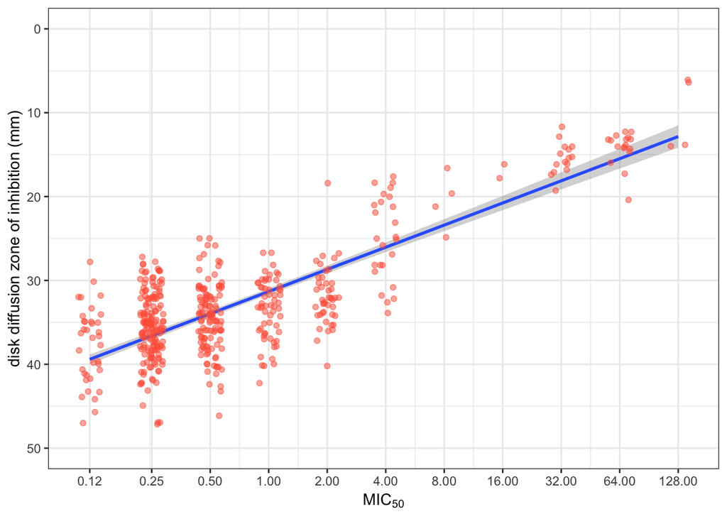

```r
gP +
  geom_smooth(method = "lm", na.rm=TRUE) +
  geom_jitter(alpha = 0.5, color = "tomato", width = 0.2)
```

And finally a statistical test to cap it all off, we’ll look for a correlation between these two variables. We’ll again turn to our non-parametric statistics, and specify that we want Spearman’s *rho* test (in this case it’s the same function as the parametric test, we just specify the method we want to use).

```r
cor_test <- cor.test(Calb_R$MIC, Calb_R$disk, method = "spearman")
cor_test
```

```
##
##  Spearman's rank correlation rho
##
## data:  Calb_R$MIC and Calb_R$disk
## S = 30336000, p-value < 2.2e-16
## alternative hypothesis: true rho is not equal to 0
## sample estimates:
##        rho
## -0.5661987
```

And we can again use the broom package to make the output more *tidy* and easier to access.

```r
tidy(cor_test)
```

```
## # A tibble: 1 x 5
##   estimate statistic  p.value method                          alternative
##      <dbl>     <dbl>    <dbl> <chr>                           <chr>
## 1   -0.566 30335647. 1.03e-42 Spearman's rank correlation rho two.sided
```

# Saving graphs

Through the GUI you can nativate over to the plot area and use the export button.

If you prefer a programatic (non-clicky) way of doing things, I usually wrap my figues in a pdf command like this:

```r
pdf(here("figures_out", "190411Calb_R_MIC_DDA.pdf"), width=4, height=4)
gP +
  geom_smooth(method = "lm", na.rm=TRUE) +
  geom_jitter(alpha = 0.5, color = "tomato", width = 0.2)
dev.off()
```

```r
system("open figures_out/190411Calb_R_MIC_DDA.pdf")
```

# Attributes

Based partially on material from [The Carpentries](https://carpentries.org/) made available under the [Creative Commons Attribution license](https://creativecommons.org/licenses/by/4.0/).  
[Five number summary](https://chemicalstatistician.wordpress.com/2013/08/12/exploratory-data-analysis-the-5-number-summary-two-different-methods-in-r-2/)